# Project: No-show Appointments

- Introduction
- Data Wrangling
- Exploratory Data Analysis
- Conclusions

## Introduction

We are going to analyze **No-show Appointments** dataset with a systematic data analysis process. The main objective of our analysis is to find what factors are highly associated with patients' non-showing up to their scheduled appointments. Our analysis will run through phases summarized below:

1.**Asking Questions:** In this phase, we will brainstorm and investigate the problem of patients’ no-showing-up to scheduled appointments with questions below:

- What factors are important for us to know in order to predict if a patient will show up for their scheduled appointment? showing-up to scheduled appointments?
- Are sending messages and scholarship highly associated with patients’ showing-up to scheduled appointments?
- Which months and days are patients showing up or not showing to their appointments?

2.**Data Wrangling:** In this phase, we will assess and clean our dataset to be able to perform our exploratory data analysis. This initial phase will include some operations such as assessing how the dataset is structured, what the data types of attributes are, checking missing data and duplicates, describing the summary statistics of the dataframe, renaming and lowering-case of the headers to facilitate queries and reaching our attributes, fixing data types issues, dropping some unnecessary attributes or rows and extracting some columns to support our validation of assumptions and data analysis.

3.**Performing Exploratory Data Analysis:** In EDA, we will focus our analysis on finding some patterns and models, and presenting some visualizations that display the correlations and associations of variables in our dataset.

4.**Drawing Conclusions:** In this phase, we are going to run some descriptive statistical analysis to answer the posed questions.

5.**Communicating Results:** In this final phase, we will provide and attach a written HTML report detailing the most important variables affecting patients’ showing-up to scheduled appointments.

```python
import numpy as np
import pandas as pd
import matplotlib.pyplot as plt
import seaborn as sns
%matplotlib inline
```

## Data Wrangling: Loading Data, Assessing Data and Cleaning Data.

### First: Loading Data

```python
# Loading the dataset
df = pd.read_csv('noshowappointments-kagglev2-may-2016.csv')
```

### Second: Assessing Data

```python
# Printing the first 5 rows of the dataset to know how the data is sructured
df.head()
```

|  | PatientId | AppointmentID | Gender | ScheduledDay | AppointmentDay | Age | Neighbourhood | Scholarship | Hipertension | Diabetes | Alcoholism | Handcap | SMS_received | No-show |
| --- | --- | --- | --- | --- | --- | --- | --- | --- | --- | --- | --- | --- | --- | --- |
| 0 | 2.987250e+13 | 5642903 | F | 2016-04-29T18:38:08Z | 2016-04-29T00:00:00Z | 62 | JARDIM DA PENHA | 0 | 1 | 0 | 0 | 0 | 0 | No |
| 1 | 5.589978e+14 | 5642503 | M | 2016-04-29T16:08:27Z | 2016-04-29T00:00:00Z | 56 | JARDIM DA PENHA | 0 | 0 | 0 | 0 | 0 | 0 | No |
| 2 | 4.262962e+12 | 5642549 | F | 2016-04-29T16:19:04Z | 2016-04-29T00:00:00Z | 62 | MATA DA PRAIA | 0 | 0 | 0 | 0 | 0 | 0 | No |
| 3 | 8.679512e+11 | 5642828 | F | 2016-04-29T17:29:31Z | 2016-04-29T00:00:00Z | 8 | PONTAL DE CAMBURI | 0 | 0 | 0 | 0 | 0 | 0 | No |
| 4 | 8.841186e+12 | 5642494 | F | 2016-04-29T16:07:23Z | 2016-04-29T00:00:00Z | 56 | JARDIM DA PENHA | 0 | 1 | 1 | 0 | 0 | 0 | No |

```python
# Printing the last 5 rows of the dataset to validate the dataset structure
df.tail()
```

|  | PatientId | AppointmentID | Gender | ScheduledDay | AppointmentDay | Age | Neighbourhood | Scholarship | Hipertension | Diabetes | Alcoholism | Handcap | SMS_received | No-show |
| --- | --- | --- | --- | --- | --- | --- | --- | --- | --- | --- | --- | --- | --- | --- |
| 110522 | 2.572134e+12 | 5651768 | F | 2016-05-03T09:15:35Z | 2016-06-07T00:00:00Z | 56 | MARIA ORTIZ | 0 | 0 | 0 | 0 | 0 | 1 | No |
| 110523 | 3.596266e+12 | 5650093 | F | 2016-05-03T07:27:33Z | 2016-06-07T00:00:00Z | 51 | MARIA ORTIZ | 0 | 0 | 0 | 0 | 0 | 1 | No |
| 110524 | 1.557663e+13 | 5630692 | F | 2016-04-27T16:03:52Z | 2016-06-07T00:00:00Z | 21 | MARIA ORTIZ | 0 | 0 | 0 | 0 | 0 | 1 | No |
| 110525 | 9.213493e+13 | 5630323 | F | 2016-04-27T15:09:23Z | 2016-06-07T00:00:00Z | 38 | MARIA ORTIZ | 0 | 0 | 0 | 0 | 0 | 1 | No |
| 110526 | 3.775115e+14 | 5629448 | F | 2016-04-27T13:30:56Z | 2016-06-07T00:00:00Z | 54 | MARIA ORTIZ | 0 | 0 | 0 | 0 | 0 | 1 | No |

```python
# Checking how many rows and columns in the dataframe
df.shape
```

```
(110527, 14)
```

```python
# Getting a general overview of the dataframe and what are the data types of each attribute
# and if there is mising data or not
df.info()
```

```
<class 'pandas.core.frame.DataFrame'>
RangeIndex: 110527 entries, 0 to 110526
Data columns (total 14 columns):
 #   Column          Non-Null Count   Dtype
---  ------          --------------   -----
 0   PatientId       110527 non-null  float64
 1   AppointmentID   110527 non-null  int64
 2   Gender          110527 non-null  object
 3   ScheduledDay    110527 non-null  object
 4   AppointmentDay  110527 non-null  object
 5   Age             110527 non-null  int64
 6   Neighbourhood   110527 non-null  object
 7   Scholarship     110527 non-null  int64
 8   Hipertension    110527 non-null  int64
 9   Diabetes        110527 non-null  int64
 10  Alcoholism      110527 non-null  int64
 11  Handcap         110527 non-null  int64
 12  SMS_received    110527 non-null  int64
 13  No-show         110527 non-null  object
dtypes: float64(1), int64(8), object(5)
memory usage: 11.8+ MB
```

```python
# Checking missing values in the dataframe
df.isnull().sum()
```

```
PatientId         0
AppointmentID     0
Gender            0
ScheduledDay      0
AppointmentDay    0
Age               0
Neighbourhood     0
Scholarship       0
Hipertension      0
Diabetes          0
Alcoholism        0
Handcap           0
SMS_received      0
No-show           0
dtype: int64
```

```python
# checking duplicated values in the dataframe
df.duplicated().sum()
```

```
0
```

```python
df.nunique()
```

```
PatientId          62299
AppointmentID     110527
Gender                 2
ScheduledDay      103549
AppointmentDay        27
Age                  104
Neighbourhood         81
Scholarship            2
Hipertension           2
Diabetes               2
Alcoholism             2
Handcap                5
SMS_received           2
No-show                2
dtype: int64
```

```python
df.Handcap.unique()
```

```
array([0, 1, 2, 3, 4], dtype=int64)
```

```python
# Presenting summary statistics of the dataframe
df.describe()
```

|  | PatientId | AppointmentID | Age | Scholarship | Hipertension | Diabetes | Alcoholism | Handcap | SMS_received |
| --- | --- | --- | --- | --- | --- | --- | --- | --- | --- |
| count | 1.105270e+05 | 1.105270e+05 | 110527.000000 | 110527.000000 | 110527.000000 | 110527.000000 | 110527.000000 | 110527.000000 | 110527.000000 |
| mean | 1.474963e+14 | 5.675305e+06 | 37.088874 | 0.098266 | 0.197246 | 0.071865 | 0.030400 | 0.022248 | 0.321026 |
| std | 2.560949e+14 | 7.129575e+04 | 23.110205 | 0.297675 | 0.397921 | 0.258265 | 0.171686 | 0.161543 | 0.466873 |
| min | 3.921784e+04 | 5.030230e+06 | -1.000000 | 0.000000 | 0.000000 | 0.000000 | 0.000000 | 0.000000 | 0.000000 |
| 25% | 4.172614e+12 | 5.640286e+06 | 18.000000 | 0.000000 | 0.000000 | 0.000000 | 0.000000 | 0.000000 | 0.000000 |
| 50% | 3.173184e+13 | 5.680573e+06 | 37.000000 | 0.000000 | 0.000000 | 0.000000 | 0.000000 | 0.000000 | 0.000000 |
| 75% | 9.439172e+13 | 5.725524e+06 | 55.000000 | 0.000000 | 0.000000 | 0.000000 | 0.000000 | 0.000000 | 1.000000 |
| max | 9.999816e+14 | 5.790484e+06 | 115.000000 | 1.000000 | 1.000000 | 1.000000 | 1.000000 | 4.000000 | 1.000000 |

### Summary of Assessing Data:

After assessing data, we found that:

1. The dataset has a shape of `110527 rows` and `14 columns`.
2. There are no missing or duplicated values in the dataset.
3. The dataframe values are unique. All has values of `0` or `1` to represent the attributes applied to a specific appointment. However, we inquired the attribute `Handcap` as it has 5 unique values from `0` up to `4` and it seems that these values represent the hancap degree.
4. Based on the dataframe assessment:
- Columns `PatientId` and `AppointmentID` are not necessary so we can drop them.
- There is one value in `Age` column with negative value of `-1`.
- There are 2 columns with inncorrect `object` data type: `ScheduledDay` and `AppointmentDay`.
- The header names don't have a standard format of python so we will rename them later.
1. From the descriptive statistics, we can found that:
- The standard deviation of variables is very small and values are clustered around the mean, except for the `Age` variable which has very high std as there is big variance in ages of patients.
- The mean of ages is `37` and all means of variables is very low. Most important, the mean of `SMS_received` is `0.32` which is a big question mark.
- The min value of Age variable is `-1` and we think it is better to drop it.

### Third: Cleaning Data: Fixing Issues Found in Assessmnet Phase

```python
# Dropping Columns PatientId and AppointmentID
df.drop(['PatientId', 'AppointmentID'], axis=1, inplace=True)
```

```python
# Droping row with value -1 in Age column
# First: we look for the row with the issue
df.query('Age == -1')
```

|  | Gender | ScheduledDay | AppointmentDay | Age | Neighbourhood | Scholarship | Hipertension | Diabetes | Alcoholism | Handcap | SMS_received | No-show |
| --- | --- | --- | --- | --- | --- | --- | --- | --- | --- | --- | --- | --- |
| 99832 | F | 2016-06-06T08:58:13Z | 2016-06-06T00:00:00Z | -1 | ROMÃO | 0 | 0 | 0 | 0 | 0 | 0 | No |

```python
# Second: we confirm that the index has the value creates the issue before dropping the row
df.Age[99832]
```

```
-1
```

```python
# Third: Dropping the Age row with 1- value
df.drop([df.index[99832]], axis =0,inplace= True)
```

```python
df.head()
```

|  | Gender | ScheduledDay | AppointmentDay | Age | Neighbourhood | Scholarship | Hipertension | Diabetes | Alcoholism | Handcap | SMS_received | No-show |
| --- | --- | --- | --- | --- | --- | --- | --- | --- | --- | --- | --- | --- |
| 0 | F | 2016-04-29T18:38:08Z | 2016-04-29T00:00:00Z | 62 | JARDIM DA PENHA | 0 | 1 | 0 | 0 | 0 | 0 | No |
| 1 | M | 2016-04-29T16:08:27Z | 2016-04-29T00:00:00Z | 56 | JARDIM DA PENHA | 0 | 0 | 0 | 0 | 0 | 0 | No |
| 2 | F | 2016-04-29T16:19:04Z | 2016-04-29T00:00:00Z | 62 | MATA DA PRAIA | 0 | 0 | 0 | 0 | 0 | 0 | No |
| 3 | F | 2016-04-29T17:29:31Z | 2016-04-29T00:00:00Z | 8 | PONTAL DE CAMBURI | 0 | 0 | 0 | 0 | 0 | 0 | No |
| 4 | F | 2016-04-29T16:07:23Z | 2016-04-29T00:00:00Z | 56 | JARDIM DA PENHA | 0 | 1 | 1 | 0 | 0 | 0 | No |

```python
# Confirming the the Age min value has been corrected
df.describe()
```

|  | Age | Scholarship | Hipertension | Diabetes | Alcoholism | Handcap | SMS_received |
| --- | --- | --- | --- | --- | --- | --- | --- |
| count | 110526.000000 | 110526.000000 | 110526.000000 | 110526.000000 | 110526.000000 | 110526.000000 | 110526.000000 |
| mean | 37.089219 | 0.098266 | 0.197248 | 0.071865 | 0.030400 | 0.022248 | 0.321029 |
| std | 23.110026 | 0.297676 | 0.397923 | 0.258266 | 0.171686 | 0.161543 | 0.466874 |
| min | 0.000000 | 0.000000 | 0.000000 | 0.000000 | 0.000000 | 0.000000 | 0.000000 |
| 25% | 18.000000 | 0.000000 | 0.000000 | 0.000000 | 0.000000 | 0.000000 | 0.000000 |
| 50% | 37.000000 | 0.000000 | 0.000000 | 0.000000 | 0.000000 | 0.000000 | 0.000000 |
| 75% | 55.000000 | 0.000000 | 0.000000 | 0.000000 | 0.000000 | 0.000000 | 1.000000 |
| max | 115.000000 | 1.000000 | 1.000000 | 1.000000 | 1.000000 | 4.000000 | 1.000000 |

```python
# Fixing data types of ScheduledDay and AppointmentDay columns
# First: coverting the data type od dates from object to datetime
df['ScheduledDay'] = pd.to_datetime(df['ScheduledDay'])
df['AppointmentDay'] = pd.to_datetime(df['AppointmentDay'])
```

```python
# Second: Confirming that both data types of ScheduledDay and AppointmentDay columns have been corrected
df.dtypes
```

```
Gender                         object
ScheduledDay      datetime64[ns, UTC]
AppointmentDay    datetime64[ns, UTC]
Age                             int64
Neighbourhood                  object
Scholarship                     int64
Hipertension                    int64
Diabetes                        int64
Alcoholism                      int64
Handcap                         int64
SMS_received                    int64
No-show                        object
dtype: object
```

```python
# Renaming column names to standard Python naming to facilitate analysis
# First: Loweringcase of all header names
df.columns = df.columns.str.lower()
```

```python
# Second: Renaming scheduledday, appointmentday and no-show column names
df.rename(columns={'scheduledday': 'scheduled_day'}, inplace=True)
df.rename(columns={'appointmentday': 'appointment_day'}, inplace=True)
df.rename(columns={'no-show': 'no_show'}, inplace=True)
```

```python
# Finally confirming that headers are lowercased and renamed
df.head()
```

|  | gender | scheduled_day | appointment_day | age | neighbourhood | scholarship | hipertension | diabetes | alcoholism | handcap | sms_received | no_show |
| --- | --- | --- | --- | --- | --- | --- | --- | --- | --- | --- | --- | --- |
| 0 | F | 2016-04-29 18:38:08+00:00 | 2016-04-29 00:00:00+00:00 | 62 | JARDIM DA PENHA | 0 | 1 | 0 | 0 | 0 | 0 | No |
| 1 | M | 2016-04-29 16:08:27+00:00 | 2016-04-29 00:00:00+00:00 | 56 | JARDIM DA PENHA | 0 | 0 | 0 | 0 | 0 | 0 | No |
| 2 | F | 2016-04-29 16:19:04+00:00 | 2016-04-29 00:00:00+00:00 | 62 | MATA DA PRAIA | 0 | 0 | 0 | 0 | 0 | 0 | No |
| 3 | F | 2016-04-29 17:29:31+00:00 | 2016-04-29 00:00:00+00:00 | 8 | PONTAL DE CAMBURI | 0 | 0 | 0 | 0 | 0 | 0 | No |
| 4 | F | 2016-04-29 16:07:23+00:00 | 2016-04-29 00:00:00+00:00 | 56 | JARDIM DA PENHA | 0 | 1 | 1 | 0 | 0 | 0 | No |

```python
# Extracting Months and Days from scheduled_day and appointment_day columns
# First: Extracting Months and Days from scheduled_day column
df['schedule_month'] = df['scheduled_day'].dt.month
df['schedule_day'] = df['scheduled_day'].dt.day

# Second: Extracting Month and Day from appointment_day column
df['app_month'] = df['appointment_day'].dt.month
df['app_day'] = df['appointment_day'].dt.day
```

```python
# Confirming extraction of Months and Days from scheduled_day and appointment_day columns
df.head()
```

|  | gender | scheduled_day | appointment_day | age | neighbourhood | scholarship | hipertension | diabetes | alcoholism | handcap | sms_received | no_show | schedule_month | schedule_day | app_month | app_day |
| --- | --- | --- | --- | --- | --- | --- | --- | --- | --- | --- | --- | --- | --- | --- | --- | --- |
| 0 | F | 2016-04-29 18:38:08+00:00 | 2016-04-29 00:00:00+00:00 | 62 | JARDIM DA PENHA | 0 | 1 | 0 | 0 | 0 | 0 | No | 4 | 29 | 4 | 29 |
| 1 | M | 2016-04-29 16:08:27+00:00 | 2016-04-29 00:00:00+00:00 | 56 | JARDIM DA PENHA | 0 | 0 | 0 | 0 | 0 | 0 | No | 4 | 29 | 4 | 29 |
| 2 | F | 2016-04-29 16:19:04+00:00 | 2016-04-29 00:00:00+00:00 | 62 | MATA DA PRAIA | 0 | 0 | 0 | 0 | 0 | 0 | No | 4 | 29 | 4 | 29 |
| 3 | F | 2016-04-29 17:29:31+00:00 | 2016-04-29 00:00:00+00:00 | 8 | PONTAL DE CAMBURI | 0 | 0 | 0 | 0 | 0 | 0 | No | 4 | 29 | 4 | 29 |
| 4 | F | 2016-04-29 16:07:23+00:00 | 2016-04-29 00:00:00+00:00 | 56 | JARDIM DA PENHA | 0 | 1 | 1 | 0 | 0 | 0 | No | 4 | 29 | 4 | 29 |

### Summary of Cleaning Data :

In cleaning data phase, we have taken the following steps:

1. Dropped Columns PatientId and AppointmentID as no need for them in our analysis.
2. Dropped the row with index `99832` and value `-1` in Age column. It seems a typo and makes an outlier in the data.
3. Fixed the data types of `ScheduledDay` and `AppointmentDay` columns to `datetime64[ns, UTC]`
4. Renamed header names to match standard Python naming and to facilitate our analysis.
5. Extracted `Months and Days` from `scheduled_day` and `appointment_day` columns to be able to perform some grouping and filtering.

## Exploratory Data Analysis

### Research Question 1: What factors are important for us to know in order to predict if a patient will show up for their scheduled appointment?

### 1. Exploring Percents of People Who Did/Didn't Showed up

```python
# Exploring the dataset in general
df['no_show'].value_counts(normalize=True)
```

```
No     0.798066
Yes    0.201934
Name: no_show, dtype: float64
```

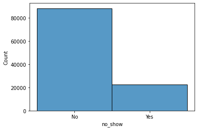

```python
# Plotting the percent of who showed up vs.who didn't
sns.histplot(data=df, x="no_show");
```

### 2. Exploring Each Attribute Individually

### Exploring Gender Attribute

```python
# Exploring the Gender proportions
df['gender'].value_counts(normalize=True)
```

```
F    0.649974
M    0.350026
Name: gender, dtype: float64
```

```python
# Exploring the correlation of gender to appointments attendance
df.groupby('no_show').gender.value_counts(normalize=True, ascending=True)
```

```
no_show  gender
No       M         0.351015
         F         0.648985
Yes      M         0.346118
         F         0.653882
Name: gender, dtype: float64
```

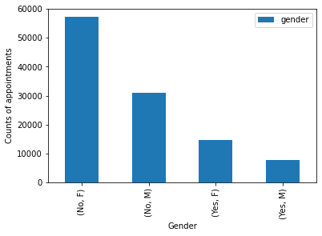

```python
# Plotting the the the correlation of gender to appointments attendance
df.groupby('no_show').gender.value_counts().plot(kind='bar')
plt.xlabel('Gender')
plt.ylabel('Counts of appointments')
plt.legend();
```

### Exploring Age Attribute

```python
# Exploring the correlation of age to appointments attendance
# Frist: Exporing the mean age of patients
df.age.mean()
```

```
37.089218826339504
```

```python
# Second: Exporing the median age of patients
df.age.median()
```

```
37.0
```

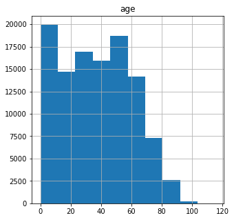

```python
# Third: Plotting the distribution of the ages of patients
df.hist('age', figsize=(5, 5));
```

```python
# Fouth: Exploring the counts of patients and how they are allocated by showin-up status
df.groupby('no_show').age.value_counts(ascending=True)
```

```
no_show  age
No       99       1
         102      2
         115      2
         100      4
         98       5
               ...
Yes      30     369
         19     394
         17     396
         1      415
         0      639
Name: age, Length: 203, dtype: int64
```

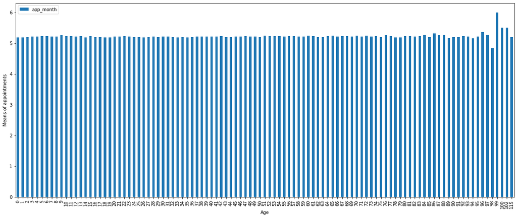

```python
df.groupby('age').app_month.mean().plot(kind='bar', figsize=(20, 8))
plt.xlabel('Age')
plt.ylabel('Means of appointments')
plt.legend();
```

### Exploring Neighbourhood Attribute

```python
# Exploring the correlation of neighbourhood to appointments attendance
df.groupby('no_show').neighbourhood.value_counts(normalize=True, ascending=False)
```

```
no_show  neighbourhood
No       JARDIM CAMBURI                 0.070879
         MARIA ORTIZ                    0.051991
         RESISTÊNCIA                    0.039963
         JARDIM DA PENHA                0.036800
         SANTA MARTHA                   0.029873
                                          ...
Yes      PONTAL DE CAMBURI              0.000538
         ILHA DO BOI                    0.000134
         ILHA DO FRADE                  0.000090
         ILHAS OCEÂNICAS DE TRINDADE    0.000090
         AEROPORTO                      0.000045
Name: neighbourhood, Length: 160, dtype: float64
```

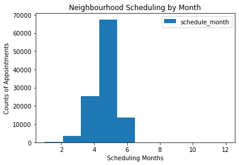

```python
df.plot(x='neighbourhood', y='schedule_month', kind='hist')
plt.xlabel('Scheduling Months')
plt.ylabel('Counts of Appointments')
plt.title('Neighbourhood Scheduling by Month')
plt.legend();
```

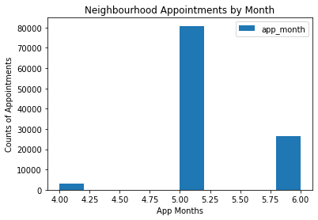

```python
df.plot(x='neighbourhood', y='app_month', kind='hist')
plt.xlabel('App Months')
plt.ylabel('Counts of Appointments')
plt.title('Neighbourhood Appointments by Month')
plt.legend();
```

### Exploring Disease Attributes

```python
# Exploring the correlation of hipertension to appointments attendance
df.groupby('no_show').hipertension.value_counts(normalize=True, ascending=False)
```

```
no_show  hipertension
No       0               0.795606
         1               0.204394
Yes      0               0.830996
         1               0.169004
Name: hipertension, dtype: float64
```

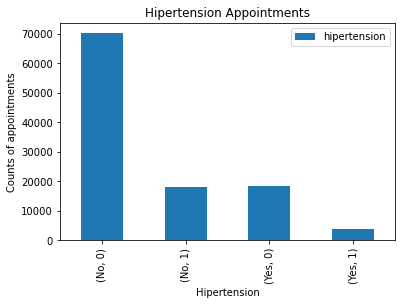

```python
df.groupby('no_show').hipertension.value_counts().plot(kind='bar')
plt.xlabel('Hipertension')
plt.ylabel('Counts of appointments')
plt.title('Hipertension Appointments')
plt.legend();
```

```python
# Exploring the correlation of diabetes to appointments attendance
df.groupby('no_show').diabetes.value_counts(normalize=True, ascending=False)
```

```
no_show  diabetes
No       0           0.926162
         1           0.073838
Yes      0           0.935929
         1           0.064071
Name: diabetes, dtype: float64
```

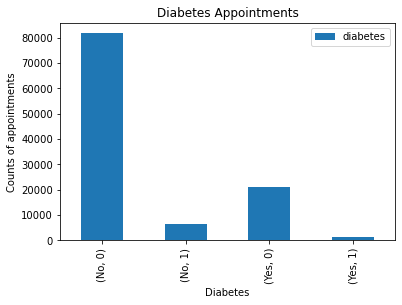

```python
df.groupby('no_show').diabetes.value_counts().plot(kind='bar')
plt.xlabel('Diabetes')
plt.ylabel('Counts of appointments')
plt.title('Diabetes Appointments')
plt.legend();
```

```python
# Exploring the correlation of alcoholism to appointments attendance
df.groupby('no_show').alcoholism.value_counts(normalize=True, ascending=False)
```

```
no_show  alcoholism
No       0             0.969583
         1             0.030417
Yes      0             0.969667
         1             0.030333
Name: alcoholism, dtype: float64
```

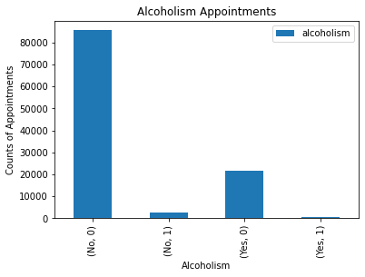

```python
df.groupby('no_show').alcoholism.value_counts().plot(kind='bar')
plt.xlabel('Alcoholism')
plt.ylabel('Counts of Appointments')
plt.title('Alcoholism Appointments')
plt.legend();
```

```python
# Exploring the correlation of handcap to appointments attendance
df.groupby('no_show').handcap.value_counts(normalize=True)
```

```
no_show  handcap
No       0          0.979208
         1          0.019001
         2          0.001655
         3          0.000113
         4          0.000023
Yes      0          0.981764
         1          0.016399
         2          0.001658
         3          0.000134
         4          0.000045
Name: handcap, dtype: float64
```

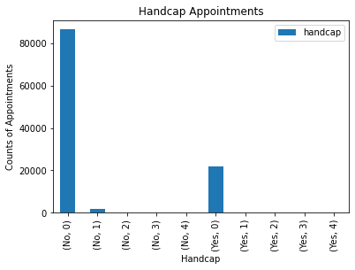

```python
df.groupby('no_show').handcap.value_counts().plot(kind='bar')
plt.xlabel('Handcap')
plt.ylabel('Counts of Appointments')
plt.title('Handcap Appointments')
plt.legend();
```

### Research Question 2: Are sending messages and scholarship highly associated with patients’ showing-up to scheduled appointments?

### Exploring SMS Receiving Attribute

```python
# Exploring the correlation of receiving messages to the appointments attendance
df.groupby('no_show').sms_received.value_counts(normalize=True, ascending=False)
```

```
no_show  sms_received
No       0               0.708663
         1               0.291337
Yes      0               0.561629
         1               0.438371
Name: sms_received, dtype: float64
```

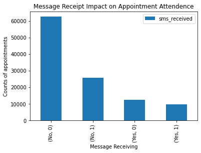

```python
df.groupby('no_show').sms_received.value_counts().plot(kind='bar')
plt.xlabel('Message Receiving')
plt.ylabel('Counts of appointments')
plt.title('Message Receipt Impact on Appointment Attendence')
plt.legend();
```

### Exploring Scholarship Attribute

```python
# Exploring the correlation of scholarship to the appointments attendance
df.groupby('no_show').scholarship.value_counts(normalize=True, ascending=False)
```

```
no_show  scholarship
No       0              0.906096
         1              0.093904
Yes      0              0.884493
         1              0.115507
Name: scholarship, dtype: float64
```

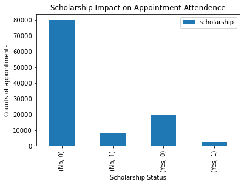

```python
# Plotting the correlation of scholarship to the appointments attendance
df.groupby('no_show').scholarship.value_counts().plot(kind='bar')
plt.xlabel('Scholarship Status')
plt.ylabel('Counts of appointments')
plt.title('Scholarship Impact on Appointment Attendence')
plt.legend();
```

### Research Question 3: Which months and days are patients showing up or not showing to their appointments?

### Exploring Months and Days Attributes

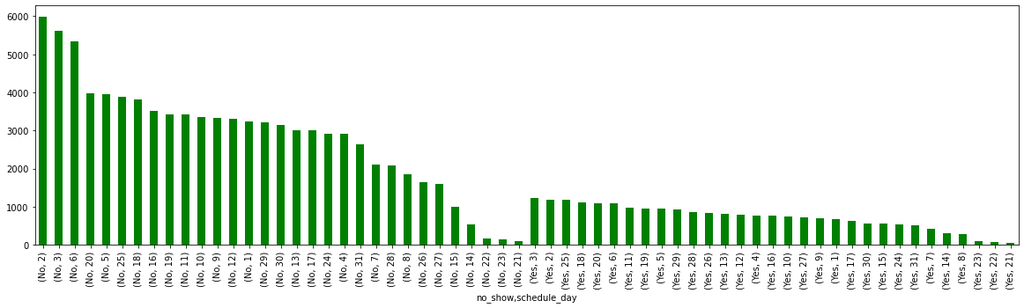

```python
# Plotting the distribution of schedule_day based on appointment attendence
df.groupby('no_show')['schedule_day'].value_counts().plot(kind='bar', figsize=[20, 5], color='g');
```

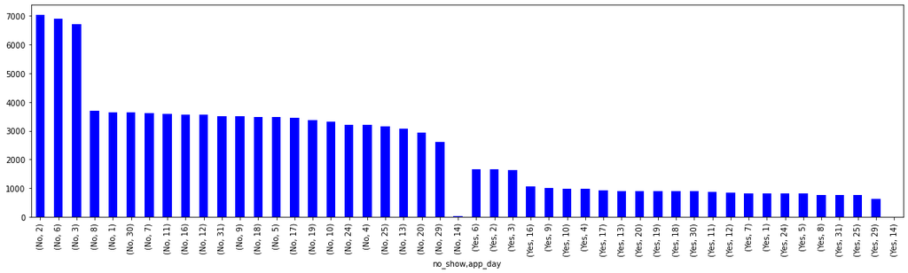

```python
# Plotting the distribution of app_day based on appointment attendence
df.groupby('no_show')['app_day'].value_counts().plot(kind='bar', figsize=[20, 5], color='b');
```

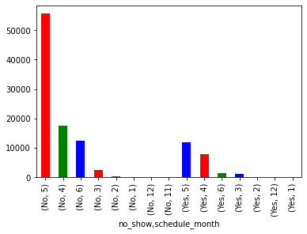

```python
# Plotting the distribution of schedule_month based on appointment attendence
df.groupby('no_show')['schedule_month'].value_counts().plot(kind='bar', color=['r', 'g', 'b']);
```

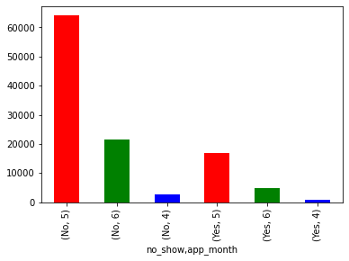

```python
# Plotting the distribution of app_month based on appointment attendence
df.groupby('no_show')['app_month'].value_counts().plot(kind='bar', color=['r', 'g', 'b']);
```

```python
# Exploring the mean of schedule_month
df.schedule_month.mean()
```

```
4.8238604491250925
```

```python
# Exploring the median of schedule_month
df.schedule_month.median()
```

```
5.0
```

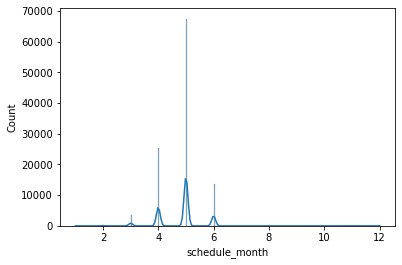

```python
# Plotting the distribution of schedule_month to the appointments attendance
sns.histplot(data=df, x="schedule_month", kde=True);
```

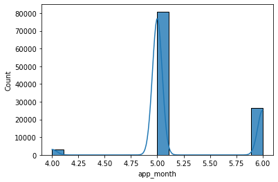

```python
# Plotting the distribution of app_month to the appointments attendance
sns.histplot(data=df, x="app_month", kde=True, alpha=.8);
```

```python
# Exploring the mean of app_month
df.app_month.mean()
```

```
5.210041076307837
```

```python
# Exploring the median of app_month
df.app_month.median()
```

```
5.0
```

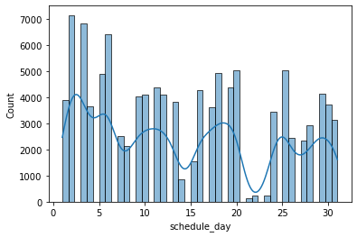

```python
# Plotting the distribution of schedule_day to the appointments attendance
sns.histplot(data=df, x="schedule_day", kde=True);
```

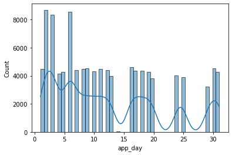

```python
# Plotting the distribution of app_day to the appointments attendance
sns.histplot(data=df, x="app_day", kde=True);
```